# Predictive States — F1 / F2 Analysis

Working notebook for the "predictive states" blog post: which states have the longest track record of voting with the National Popular Vote (NPV) winner and/or the Electoral College (EC) winner, and how that's changed over time.

Two formalizations are used throughout (see `docs/predictive-states-methodology` on the blog for the full derivation):

- **F1 — longest streak tolerating *k* misses.** For a given tolerance `k`, the longest contiguous run of elections with at most `k` misses. Used for **display** — it's the intuitive "27 of 28" framing.
- **F2 — baseline-centered maximum-subarray score.** Each election scores `(1 - p)` on a match and `-p` on a miss, where `p` is the (possibly time-varying) baseline hit rate that election year; the best-scoring contiguous window is found via a Kadane's-algorithm-style scan (this is a CUSUM / change-point statistic). Used for **selecting/ranking** which states are worth featuring, since it self-tunes its own miss tolerance and isn't dominated by short lucky streaks the way a bare "% correct" would be.

Run all cells top-to-bottom once, then each state section below is independent and can be re-run / exported on its own — cells are tagged with the state's postal code plus its narrative category (see index below) so you can filter by tag when exporting individual sections.

## State index

| Category | States |
| --- | --- |
| Core — long-run F2-dominant bellwether | IL, OH, PA, NY, CA, MO |
| Used to be — historical bellwether, now gone | IN |
| Modern predictive state | NV, NM |
| Bellwether that drifted during the Bush era | TN |
| Current predictive bloc ("Blue Wall") | WI, MI |
| Honorable mention — used to be swingy, locked in since 1992 | DE, MD, CT, NJ |

## Setup

```python
import pandas as pd
import numpy as np
import matplotlib.pyplot as plt
from IPython.display import display, Markdown

# Set to False if you want light-background plots (e.g. to match a light blog theme).
DARK_MODE = True
if DARK_MODE:
    plt.style.use("dark_background")

ACCENT = "#4FC3F7"
HIGHLIGHT = "#FFB300"
MISS_COLOR = "#EF5350"

DATA_DIR = "data"   # expects results_1789_2024.csv and presidential_margins.csv here
```

```python
results = pd.read_csv(f"{DATA_DIR}/results_1789_2024.csv")
margins = pd.read_csv(f"{DATA_DIR}/presidential_margins.csv")

# collapse to (year, state, unit) grain -- unit==state drops congressional-district
# splits (ME/NE post-2008, and the historical KY/MD/NC/TN/NY district splits).
# Change this filter if you want to analyze districts as their own units instead.
_grp = results.groupby(["year", "state", "unit"], as_index=False).agg(
    matches_npv=("matches_npv", "first"),
    matches_ec=("matches_ec", "first"),
)
statelevel = _grp[_grp.unit == _grp.state].copy()

# state's own popular-vote winner (plurality of raw_votes) per (year, state)
_sl = results[results.state == results.unit].dropna(subset=["raw_votes"]).copy()
_idx = _sl.groupby(["year", "state"])["raw_votes"].idxmax()
state_winner = _sl.loc[_idx, ["year", "state", "candidate", "party"]].rename(
    columns={"candidate": "state_cand", "party": "state_party"}
)

METRIC_LABEL = {"matches_npv": "National Popular Vote", "matches_ec": "Electoral College"}

# baselines for F2: a single pooled constant, and a per-election-year rate
YEARLY_P = {m: statelevel.groupby("year")[m].mean().to_dict() for m in ["matches_npv", "matches_ec"]}
POOLED_P = {m: statelevel[m].dropna().mean() for m in ["matches_npv", "matches_ec"]}

print("Loaded:", len(results), "candidate-level rows /", len(statelevel), "state-year rows")
print("Pooled baseline hit rates:", {k: round(v, 3) for k, v in POOLED_P.items()})

# which years provide the highest/lowest hit rates for each metric
for m in ["matches_npv", "matches_ec"]:
    yearly = YEARLY_P[m]
    sorted_years = sorted(yearly.items(), key=lambda x: x[1], reverse=True)
    print(f"Top years for {METRIC_LABEL[m]}:", sorted_years[:5])
    print(f"Bottom years for {METRIC_LABEL[m]}:", sorted_years[-5:])
```

```
Loaded: 10360 candidate-level rows / 2227 state-year rows
Pooled baseline hit rates: {'matches_npv': np.float64(0.682), 'matches_ec': np.float64(0.691)}
Top years for National Popular Vote: [(1789, 1.0), (1792, 1.0), (1804, 1.0), (1816, 1.0), (1820, 1.0)]
Bottom years for National Popular Vote: [(1876, 0.4857142857142857), (1880, 0.4722222222222222), (1960, 0.4583333333333333), (2000, 0.40816326530612246), (2016, 0.40816326530612246)]
Top years for Electoral College: [(1789, 1.0), (1792, 1.0), (1820, 1.0), (1936, 0.9782608695652174), (1972, 0.9591836734693877)]
Bottom years for Electoral College: [(1888, 0.5), (1976, 0.4897959183673469), (1880, 0.4722222222222222), (1824, 0.4583333333333333), (1960, 0.4583333333333333)]
```

## Core functions: F1 and F2

```python
def _valid_pairs(state, metric):
    """(year, bool) pairs for a state's valid (non-NaN) observations, sorted by year."""
    sub = statelevel[statelevel.state == state].sort_values("year")
    return [(y, bool(v)) for y, v in zip(sub.year, sub[metric]) if pd.notna(v)]


def longest_run_at_most_k_misses(bits, k):
    """F1: classic sliding-window / 'longest subarray with at most k zeros'. O(n)."""
    left = 0
    misses = 0
    best = 0
    for right, b in enumerate(bits):
        if not b:
            misses += 1
        while misses > k:
            if not bits[left]:
                misses -= 1
            left += 1
        best = max(best, right - left + 1)
    return best


def f1_curve(state, metric, kmax=3):
    """f_s(k) for k = 0..kmax -- the whole tolerance curve, not just one k."""
    bits = [b for _, b in _valid_pairs(state, metric)]
    return [longest_run_at_most_k_misses(bits, k) for k in range(kmax + 1)]
```

```python
def max_subarray_score(pairs, p_of_year):
    """F2 core: Kadane's algorithm on the baseline-centered score.
    p_of_year: dict {year: p} for a time-varying baseline, or a float constant."""
    best, best_i, best_j = -1e9, 0, 0
    cur, cur_start = 0.0, 0
    for i, (y, b) in enumerate(pairs):
        p = p_of_year[y] if isinstance(p_of_year, dict) else p_of_year
        s = (1 - p) if b else -p
        if cur <= 0:
            cur, cur_start = s, i
        else:
            cur += s
        if cur > best:
            best, best_i, best_j = cur, cur_start, i
    return best, best_i, best_j


def f2_window(state, metric, baseline="time_varying"):
    """Returns the best-scoring window for (state, metric, baseline choice), or None."""
    pairs = _valid_pairs(state, metric)
    if len(pairs) < 3:
        return None
    p_of_year = YEARLY_P[metric] if baseline == "time_varying" else POOLED_P[metric]
    score, i, j = max_subarray_score(pairs, p_of_year)
    window = pairs[i : j + 1]
    length = len(window)
    hits = sum(1 for _, b in window if b)
    return dict(
        state=state, metric=metric, baseline=baseline,
        start=window[0][0], end=window[-1][0], length=length,
        hits=hits, misses=length - hits,
        miss_years=[y for y, b in window if not b],
        score=round(float(score), 2),
    )


def headline_metric(state):
    """Whichever metric has the stronger time-varying F2 score -- used to pick the chart."""
    wec, wnpv = f2_window(state, "matches_ec", "time_varying"), f2_window(state, "matches_npv", "time_varying")
    if wec is None:
        return "matches_npv"
    if wnpv is None:
        return "matches_ec"
    return "matches_ec" if wec["score"] >= wnpv["score"] else "matches_npv"
```

## Supplementary context: party flips and margins

```python
def last_flip_year(state, through_year=2024):
    """Most recent year the state's OWN popular-vote winner changed party."""
    sub = state_winner[(state_winner.state == state) & (state_winner.year <= through_year)].sort_values("year")
    parties, years = sub.state_party.tolist(), sub.year.tolist()
    for i in range(len(parties) - 1, 0, -1):
        if parties[i] != parties[i - 1]:
            return years[i]
    return None


def flips_in_window(state, y0, y1):
    """How many times the state's own winner changed party within [y0, y1]."""
    sub = state_winner[(state_winner.state == state) & (state_winner.year >= y0) & (state_winner.year <= y1)].sort_values("year")
    parties = sub.state_party.tolist()
    return sum(1 for a, b in zip(parties, parties[1:]) if a != b)


def margin_snapshot(state, years=(2016, 2020, 2024)):
    """Raw votes + margin vs. national margin for the most recent elections."""
    sub = margins[(margins.abbr == state) & (margins.year.isin(years))].sort_values("year")
    if sub.empty:
        return pd.DataFrame()
    return pd.DataFrame({
        "Year": sub.year.values,
        "D Votes": sub.D_votes.astype("Int64").values,
        "R Votes": sub.R_votes.astype("Int64").values,
        "Raw Margin (D-R)": (sub.D_votes - sub.R_votes).astype("Int64").values,
        "State Margin %": (sub.pres_margin * 100).round(1).values,
        "National Margin %": (sub.national_margin * 100).round(1).values,
        "Relative Margin %": (sub.relative_margin * 100).round(1).values,
    }).reset_index(drop=True)
```

```python
def cusum_plot(state, metric=None, figsize=(8, 3.2)):
    """The F2 random walk: cumulative baseline-centered score over the state's
    full valid history, with the discovered best window shaded and its
    misses marked."""
    metric = metric or headline_metric(state)
    pairs = _valid_pairs(state, metric)
    w = f2_window(state, metric, "time_varying")
    years = [y for y, _ in pairs]

    running, cum = 0.0, []
    for y, b in pairs:
        running += (1 - YEARLY_P[metric][y]) if b else -YEARLY_P[metric][y]
        cum.append(running)

    fig, ax = plt.subplots(figsize=figsize)
    # x-tick spacing of 20 years
    ax.set_xticks(range(min(years), max(years) + 1, 20))
    ax.set_xticklabels(range(min(years), max(years) + 1, 20), rotation=45)
    ax.axhline(0, color="gray", linewidth=0.8, linestyle="--")
    ax.plot(years, cum, color=ACCENT, linewidth=1.6, marker="o", markersize=3)

    if w:
        ax.axvspan(w["start"] - 1, w["end"] + 1, color=HIGHLIGHT, alpha=0.15)
        # label the window start and end
        ax.text(w["start"], cum[years.index(w["start"])], f"{w['start']}", color=HIGHLIGHT, fontsize=8, ha="right", va="bottom")
        ax.text(w["end"], cum[years.index(w["end"])], f"{w['end']}", color=HIGHLIGHT, fontsize=8, ha="left", va="bottom")
        # label the missed years
        for my in w["miss_years"]:
            ax.plot(my, cum[years.index(my)], "o", color=MISS_COLOR, markersize=6, zorder=5)
            # place the year label far below
            ax.text(my, cum[years.index(my)] - 0.1 * max(cum), f"{my}", color=MISS_COLOR, fontsize=8, ha="center", va="bottom")

    ax.set_title(f"{state} \u2014 cumulative excess over baseline ({METRIC_LABEL[metric]})", fontsize=10)
    ax.set_xlabel("Election year")
    ax.set_ylabel("Cumulative score")
    fig.tight_layout()
    return fig
```

## State spotlight renderer

```python
CATEGORY_LABEL = {
    "core": "Core \u2014 long-run F2-dominant bellwether",
    "used-to-be": "Used to be \u2014 historical bellwether, now gone",
    "modern-predictive": "Modern predictive state",
    "recent-drift": "Bellwether that drifted during the Bush era",
    "modern-bloc": "Current predictive bloc (\"Blue Wall\")",
    "honorable-mention": "Honorable mention \u2014 used to be swingy, locked in since 1992",
}

def render_spotlight(state, category=None):
    label = CATEGORY_LABEL.get(category, "")
    display(Markdown(f"### {state}" + (f"\n*{label}*" if label else "")))

    # F1 table
    f1_df = pd.DataFrame(
        [[METRIC_LABEL[m]] + f1_curve(state, m, kmax=3) for m in ["matches_ec", "matches_npv"]],
        columns=["Metric", "k=0", "k=1", "k=2", "k=3"],
    )
    display(Markdown("**F1 \u2014 longest streak tolerating *k* misses**"))
    display(f1_df)

    # F2 table
    f2_rows = []
    for m in ["matches_ec", "matches_npv"]:
        for b, blabel in [("pooled", "constant pooled"), ("time_varying", "time-varying")]:
            w = f2_window(state, m, b)
            if w is None:
                continue
            f2_rows.append([
                METRIC_LABEL[m], blabel, f"{w['start']}\u2013{w['end']}", w["length"],
                w["hits"], w["misses"], ", ".join(map(str, w["miss_years"])) or "\u2014", w["score"],
            ])
    f2_df = pd.DataFrame(f2_rows, columns=["Metric", "Baseline", "Window", "Length", "Hits", "Misses", "Miss Years", "Score"])
    display(Markdown("**F2 \u2014 baseline-centered best window (used for selection/ranking)**"))
    display(f2_df)

    # party context
    ctx_rows = []
    for m in ["matches_ec", "matches_npv"]:
        w = f2_window(state, m, "time_varying")
        if w is None:
            continue
        ctx_rows.append([METRIC_LABEL[m], f"{w['start']}\u2013{w['end']}", flips_in_window(state, w["start"], w["end"])])
    ctx_df = pd.DataFrame(ctx_rows, columns=["Metric", "F2 Window", "Party Flips Within Window"])
    lf = last_flip_year(state)
    display(Markdown(f"**Party context** \u2014 {state} last changed which party it voted for in **{lf}**."))
    display(ctx_df)

    # margin snapshot
    display(Markdown("**Recent margin snapshot**"))
    display(margin_snapshot(state))

    # chart
    cusum_plot(state, metric="matches_ec")
    cusum_plot(state, metric="matches_npv")
    plt.show()
```

## Top States by F2 metric

```python
CURATED = {
    "IL": "core", "OH": "core", "PA": "core", "NY": "core", "CA": "core", "MO": "core",
    "IN": "used-to-be",
    "NV": "modern-predictive", "NM": "modern-predictive",
    "TN": "recent-drift",
    "WI": "modern-bloc", "MI": "modern-bloc",
    "DE": "honorable-mention", "MD": "honorable-mention", "CT": "honorable-mention", "NJ": "honorable-mention",
}


def build_score_table():
    """Per-state table of all 4 F2 scores (metric x baseline), plus combos:
    *_robust = min(pooled, time_varying) for that metric -- discounts a score
    that only looks good under one baseline choice. headline = min(ec_robust,
    npv_robust) -- a state only ranks high here if EC and NPV both agree it's
    strong. specialist = max(ec_robust, npv_robust) -- the best single-axis
    case, tagged with which metric it leans on and how recent that window is,
    since a strong-but-stale run (e.g. ending decades ago) reads very
    differently from a strong-and-current one at the same score."""
    rows = []
    for state in sorted(statelevel.state.unique()):
        rec = {"state": state}
        for metric, mkey in [("matches_ec", "ec"), ("matches_npv", "npv")]:
            for baseline, bkey in [("pooled", "pool"), ("time_varying", "tv")]:
                w = f2_window(state, metric, baseline)
                rec[f"{mkey}_{bkey}"] = w["score"] if w else np.nan
                rec[f"{mkey}_{bkey}_end"] = w["end"] if w else np.nan
        rows.append(rec)
    df = pd.DataFrame(rows).set_index("state")
    df["ec_robust"] = df[["ec_pool", "ec_tv"]].min(axis=1)
    df["npv_robust"] = df[["npv_pool", "npv_tv"]].min(axis=1)
    df["headline"] = df[["ec_robust", "npv_robust"]].min(axis=1)
    df["specialist"] = df[["ec_robust", "npv_robust"]].max(axis=1)
    df["specialist_metric"] = np.where(df["ec_robust"] >= df["npv_robust"], "EC", "NPV")
    df["specialist_end"] = np.where(
        df["specialist_metric"] == "EC",
        df[["ec_pool_end", "ec_tv_end"]].min(axis=1),
        df[["npv_pool_end", "npv_tv_end"]].min(axis=1),
    )
    return df


score_table = build_score_table()

# --- raw scores: where do the 4 individual rankings agree / disagree? ---
RAW_COLS = {
    "ec_pool": "EC × pooled", "ec_tv": "EC × time-varying",
    "npv_pool": "NPV × pooled", "npv_tv": "NPV × time-varying",
}
display(Markdown("### Top 12 by each raw score"))
for col, label in RAW_COLS.items():
    top = score_table[col].sort_values(ascending=False).head(12)
    display(Markdown(f"**{label}**"))
    display(pd.DataFrame({
        "Score": top.round(2).values,
        "Curated category": [CURATED.get(s, "—") for s in top.index],
    }, index=top.index))

# --- combined headline ranking: states where EC and NPV, pooled and time-varying, all agree ---
display(Markdown(
    "### Headline ranking — `min` across all 4 scores\n\n"
    "A state only scores well here if every metric × baseline combo agrees "
    "it's strong. This is what should recover the **core** / **modern-predictive** tier."
))
headline_view = score_table[["headline", "specialist", "specialist_metric", "specialist_end"]] \
    .sort_values("headline", ascending=False).round(2)
headline_view["Curated category"] = [CURATED.get(s, "—") for s in headline_view.index]
display(headline_view.head(18))

# --- specialists: states that lean hard on one metric, with how current that lean is ---
display(Markdown(
    "### Single-axis specialists (not already above) — `max` of the robust scores\n\n"
    "States that are strong on EC *or* NPV but not both. `specialist_end` is the "
    "last year in that metric's window — a specialist whose window is current "
    "(the last few cycles) reads very differently from one whose best run ended "
    "decades ago, even at a similar score. This is where **modern-bloc** and "
    "**honorable-mention** states should show up, alongside any un-curated "
    "states worth a second look."
))
already_shown = set(headline_view.head(18).index)
specialist_view = score_table.loc[~score_table.index.isin(already_shown)] \
    .sort_values("specialist", ascending=False)
specialist_view = specialist_view[["headline", "specialist", "specialist_metric", "specialist_end"]].round(2)
specialist_view["Curated category"] = [CURATED.get(s, "—") for s in specialist_view.index]
display(specialist_view.head(15))
```

Top 12 by each raw score

**EC × pooled**

| state | Score | Curated category |
| --- | --- | --- |
| IL | 8.91 | core |
| OH | 8.37 | core |
| PA | 8.32 | core |
| NY | 7.53 | core |
| MO | 7.04 | core |
| NV | 7.04 | modern-predictive |
| CA | 6.44 | core |
| NM | 6.04 | modern-predictive |
| IN | 5.59 | used-to-be |
| TN | 5.42 | recent-drift |
| NJ | 5.35 | honorable-mention |
| DE | 5.35 | honorable-mention |

**EC × time-varying**

| state | Score | Curated category |
| --- | --- | --- |
| IL | 8.44 | core |
| PA | 8.40 | core |
| OH | 8.20 | core |
| NY | 6.72 | core |
| NV | 6.18 | modern-predictive |
| IN | 5.79 | used-to-be |
| MO | 5.62 | core |
| CA | 5.61 | core |
| WI | 5.08 | modern-bloc |
| NM | 4.90 | modern-predictive |
| NH | 4.79 | — |
| FL | 4.24 | — |

**NPV × pooled**

| state | Score | Curated category |
| --- | --- | --- |
| IL | 8.19 | core |
| NM | 7.89 | modern-predictive |
| NY | 7.56 | core |
| NV | 7.21 | modern-predictive |
| NJ | 7.15 | honorable-mention |
| MD | 7.11 | honorable-mention |
| DE | 7.11 | honorable-mention |
| CT | 7.02 | honorable-mention |
| MO | 6.62 | core |
| PA | 6.56 | core |
| OH | 6.53 | core |
| CA | 6.48 | core |

**NPV × time-varying**

| state | Score | Curated category |
| --- | --- | --- |
| IL | 8.31 | core |
| NY | 7.81 | core |
| NJ | 7.28 | honorable-mention |
| DE | 7.28 | honorable-mention |
| CT | 7.19 | honorable-mention |
| NM | 7.16 | modern-predictive |
| MD | 7.11 | honorable-mention |
| NV | 6.55 | modern-predictive |
| CA | 6.12 | core |
| PA | 5.90 | core |
| OH | 5.59 | core |
| IN | 5.52 | used-to-be |

Headline ranking — `min` across all 4 scores

A state only scores well here if every metric × baseline combo agrees it's strong. This is what should recover the **core** / **modern-predictive** tier.

| state | headline | specialist | specialist_metric | specialist_end | Curated category |
| --- | --- | --- | --- | --- | --- |
| IL | 8.19 | 8.44 | EC | 1996 | core |
| NY | 6.72 | 7.56 | NPV | 2020 | core |
| NV | 6.18 | 6.55 | NPV | 2024 | modern-predictive |
| PA | 5.90 | 8.32 | EC | 2024 | core |
| CA | 5.61 | 6.12 | NPV | 2020 | core |
| OH | 5.59 | 8.20 | EC | 2016 | core |
| IN | 5.21 | 5.59 | EC | 1936 | used-to-be |
| MO | 5.15 | 5.62 | EC | 2004 | core |
| NM | 4.90 | 7.16 | NPV | 2020 | modern-predictive |
| DE | 4.16 | 7.11 | NPV | 2020 | honorable-mention |
| MD | 4.16 | 7.11 | NPV | 2020 | honorable-mention |
| NJ | 4.16 | 7.15 | NPV | 2020 | honorable-mention |
| RI | 3.67 | 4.19 | EC | 1964 | — |
| MA | 3.67 | 4.06 | EC | 1964 | — |
| NH | 3.67 | 4.79 | EC | 2000 | — |
| WI | 3.51 | 4.99 | EC | 2024 | modern-bloc |
| MT | 3.46 | 3.62 | EC | 1992 | — |
| CT | 3.26 | 7.02 | NPV | 2020 | honorable-mention |

Single-axis specialists (not already above) — `max` of the robust scores

| state | headline | specialist | specialist_metric | specialist_end | Curated category |
| --- | --- | --- | --- | --- | --- |
| WV | 3.12 | 4.66 | NPV | 1964 | — |
| FL | 3.02 | 4.24 | EC | 2016 | — |
| MN | 2.67 | 4.06 | EC | 1964 | — |
| TN | 3.20 | 4.00 | EC | 2004 | recent-drift |
| NC | 3.02 | 3.67 | NPV | 1892 | — |
| OR | 2.83 | 3.67 | NPV | 2020 | — |
| LA | 2.54 | 3.40 | EC | 1856 | — |
| IA | 2.59 | 3.26 | EC | 1936 | — |
| KY | 2.42 | 3.22 | EC | 2004 | — |
| ID | 3.19 | 3.19 | EC | 1972 | — |
| WA | 2.52 | 3.18 | NPV | 2020 | — |
| MI | 2.47 | 2.99 | EC | 2024 | modern-bloc |
| ND | 2.87 | 2.87 | EC | 1936 | — |
| KS | 2.38 | 2.81 | EC | 1936 | — |
| VT | 2.02 | 2.76 | NPV | 2020 | — |

## State spotlights

#### IL

IL

*Core — long-run F2-dominant bellwether*

**F1 — longest streak tolerating *k* misses**

|  | Metric | k=0 | k=1 | k=2 | k=3 |
| --- | --- | --- | --- | --- | --- |
| 0 | Electoral College | 14 | 22 | 31 | 37 |
| 1 | National Popular Vote | 14 | 21 | 28 | 33 |

**F2 — baseline-centered best window (used for selection/ranking)**

|  | Metric | Baseline | Window | Length | Hits | Misses | Miss Years | Score |
| --- | --- | --- | --- | --- | --- | --- | --- | --- |
| 0 | Electoral College | constant pooled | 1820–1996 | 45 | 40 | 5 | 1840, 1848, 1884, 1916, 1976 | 8.91 |
| 1 | Electoral College | time-varying | 1824–1996 | 44 | 39 | 5 | 1840, 1848, 1884, 1916, 1976 | 8.44 |
| 2 | National Popular Vote | constant pooled | 1820–2020 | 51 | 43 | 8 | 1840, 1848, 1876, 1884, 1888, 1916, 1976, 2004 | 8.19 |
| 3 | National Popular Vote | time-varying | 1824–2020 | 50 | 42 | 8 | 1840, 1848, 1876, 1884, 1888, 1916, 1976, 2004 | 8.31 |

**Party context** — IL last changed which party it voted for in **1992**.

|  | Metric | F2 Window | Party Flips Within Window |
| --- | --- | --- | --- |
| 0 | Electoral College | 1824–1996 | 11 |
| 1 | National Popular Vote | 1824–2020 | 11 |

**Recent margin snapshot**

|  | Year | D Votes | R Votes | Raw Margin (D-R) | State Margin % | National Margin % | Relative Margin % |
| --- | --- | --- | --- | --- | --- | --- | --- |
| 0 | 2016 | 3090729 | 2146015 | 944714 | 17.1 | 2.1 | 15.0 |
| 1 | 2020 | 3471915 | 2446891 | 1025024 | 17.0 | 4.5 | 12.5 |
| 2 | 2024 | 3062863 | 2449079 | 613784 | 10.9 | -1.5 | 12.4 |

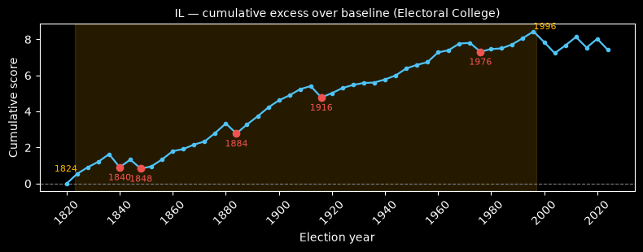

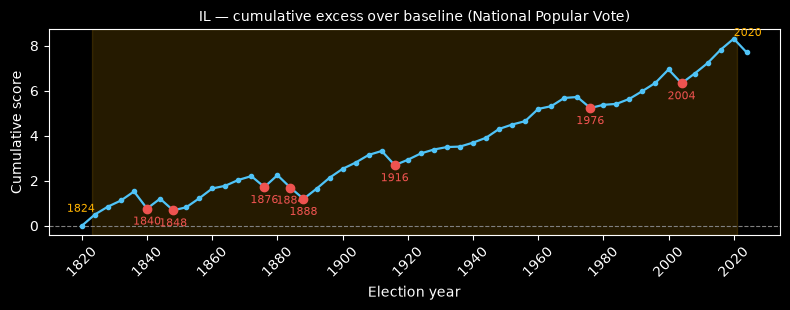

```python
render_spotlight("IL", category="core")
```

#### OH

OH

*Core — long-run F2-dominant bellwether*

**F1 — longest streak tolerating *k* misses**

|  | Metric | k=0 | k=1 | k=2 | k=3 |
| --- | --- | --- | --- | --- | --- |
| 0 | Electoral College | 14 | 18 | 31 | 33 |
| 1 | National Popular Vote | 12 | 16 | 26 | 30 |

**F2 — baseline-centered best window (used for selection/ranking)**

|  | Metric | Baseline | Window | Length | Hits | Misses | Miss Years | Score |
| --- | --- | --- | --- | --- | --- | --- | --- | --- |
| 0 | Electoral College | constant pooled | 1860–2016 | 40 | 36 | 4 | 1884, 1892, 1944, 1960 | 8.37 |
| 1 | Electoral College | time-varying | 1860–2016 | 40 | 36 | 4 | 1884, 1892, 1944, 1960 | 8.20 |
| 2 | National Popular Vote | constant pooled | 1896–2012 | 30 | 27 | 3 | 1944, 1960, 2000 | 6.53 |
| 3 | National Popular Vote | time-varying | 1896–2012 | 30 | 27 | 3 | 1944, 1960, 2000 | 5.59 |

**Party context** — OH last changed which party it voted for in **2016**.

|  | Metric | F2 Window | Party Flips Within Window |
| --- | --- | --- | --- |
| 0 | Electoral College | 1860–2016 | 14 |
| 1 | National Popular Vote | 1896–2012 | 13 |

**Recent margin snapshot**

|  | Year | D Votes | R Votes | Raw Margin (D-R) | State Margin % | National Margin % | Relative Margin % |
| --- | --- | --- | --- | --- | --- | --- | --- |
| 0 | 2016 | 2394164 | 2841005 | -446841 | -8.1 | 2.1 | -10.2 |
| 1 | 2020 | 2679165 | 3154834 | -475669 | -8.0 | 4.5 | -12.5 |
| 2 | 2024 | 2533699 | 3180116 | -646417 | -11.2 | -1.5 | -9.7 |

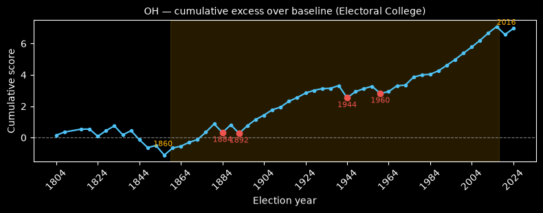

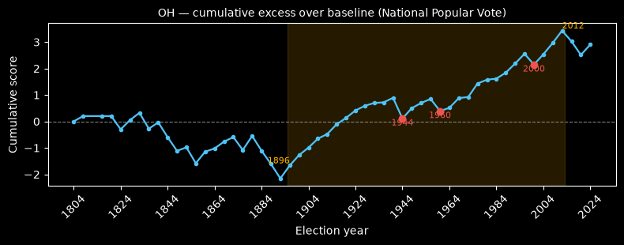

```python
render_spotlight("OH", category="core")
```

#### PA

PA

*Core — long-run F2-dominant bellwether*

**F1 — longest streak tolerating *k* misses**

|  | Metric | k=0 | k=1 | k=2 | k=3 |
| --- | --- | --- | --- | --- | --- |
| 0 | Electoral College | 20 | 22 | 27 | 29 |
| 1 | National Popular Vote | 17 | 19 | 21 | 22 |

**F2 — baseline-centered best window (used for selection/ranking)**

|  | Metric | Baseline | Window | Length | Hits | Misses | Miss Years | Score |
| --- | --- | --- | --- | --- | --- | --- | --- | --- |
| 0 | Electoral College | constant pooled | 1800–2024 | 56 | 47 | 9 | 1884, 1892, 1912, 1916, 1932, 1948, 1968, 2000... | 8.32 |
| 1 | Electoral College | time-varying | 1800–2024 | 56 | 47 | 9 | 1884, 1892, 1912, 1916, 1932, 1948, 1968, 2000... | 8.40 |
| 2 | National Popular Vote | constant pooled | 1804–2000 | 49 | 40 | 9 | 1876, 1884, 1888, 1892, 1912, 1916, 1932, 1948... | 6.56 |
| 3 | National Popular Vote | time-varying | 1808–2024 | 54 | 43 | 11 | 1876, 1884, 1888, 1892, 1912, 1916, 1932, 1948... | 5.90 |

**Party context** — PA last changed which party it voted for in **2024**.

|  | Metric | F2 Window | Party Flips Within Window |
| --- | --- | --- | --- |
| 0 | Electoral College | 1800–2024 | 18 |
| 1 | National Popular Vote | 1808–2024 | 18 |

**Recent margin snapshot**

|  | Year | D Votes | R Votes | Raw Margin (D-R) | State Margin % | National Margin % | Relative Margin % |
| --- | --- | --- | --- | --- | --- | --- | --- |
| 0 | 2016 | 2926441 | 2970733 | -44292 | -0.7 | 2.1 | -2.8 |
| 1 | 2020 | 3458229 | 3377674 | 80555 | 1.2 | 4.5 | -3.3 |
| 2 | 2024 | 3423042 | 3543308 | -120266 | -1.7 | -1.5 | -0.2 |

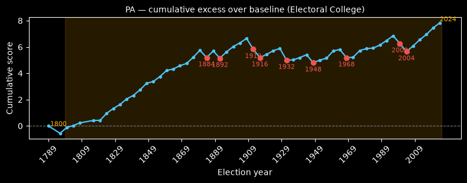

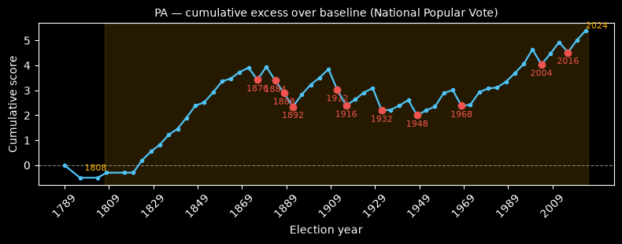

```python
render_spotlight("PA", category="core")
```

#### NY

NY

*Core — long-run F2-dominant bellwether*

**F1 — longest streak tolerating *k* misses**

|  | Metric | k=0 | k=1 | k=2 | k=3 |
| --- | --- | --- | --- | --- | --- |
| 0 | Electoral College | 9 | 17 | 22 | 27 |
| 1 | National Popular Vote | 7 | 14 | 19 | 24 |

**F2 — baseline-centered best window (used for selection/ranking)**

|  | Metric | Baseline | Window | Length | Hits | Misses | Miss Years | Score |
| --- | --- | --- | --- | --- | --- | --- | --- | --- |
| 0 | Electoral College | constant pooled | 1792–1984 | 47 | 40 | 7 | 1824, 1856, 1868, 1876, 1916, 1948, 1968 | 7.53 |
| 1 | Electoral College | time-varying | 1796–1984 | 46 | 39 | 7 | 1824, 1856, 1868, 1876, 1916, 1948, 1968 | 6.72 |
| 2 | National Popular Vote | constant pooled | 1828–2020 | 49 | 41 | 8 | 1856, 1868, 1888, 1916, 1948, 1968, 1988, 2004 | 7.56 |
| 3 | National Popular Vote | time-varying | 1828–2020 | 49 | 41 | 8 | 1856, 1868, 1888, 1916, 1948, 1968, 1988, 2004 | 7.81 |

**Party context** — NY last changed which party it voted for in **1988**.

|  | Metric | F2 Window | Party Flips Within Window |
| --- | --- | --- | --- |
| 0 | Electoral College | 1796–1984 | 21 |
| 1 | National Popular Vote | 1828–2020 | 22 |

**Recent margin snapshot**

|  | Year | D Votes | R Votes | Raw Margin (D-R) | State Margin % | National Margin % | Relative Margin % |
| --- | --- | --- | --- | --- | --- | --- | --- |
| 0 | 2016 | 4556124 | 2819534 | 1736590 | 22.5 | 2.1 | 20.4 |
| 1 | 2020 | 5244886 | 3251997 | 1992889 | 23.1 | 4.5 | 18.7 |
| 2 | 2024 | 4619195 | 3578899 | 1040296 | 12.6 | -1.5 | 14.1 |

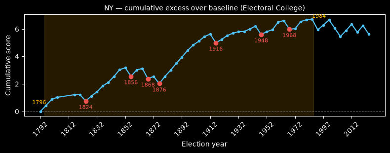

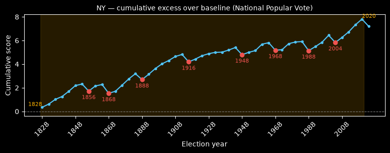

```python
render_spotlight("NY", category="core")
```

#### CA

CA

*Core — long-run F2-dominant bellwether*

**F1 — longest streak tolerating *k* misses**

|  | Metric | k=0 | k=1 | k=2 | k=3 |
| --- | --- | --- | --- | --- | --- |
| 0 | Electoral College | 11 | 18 | 22 | 28 |
| 1 | National Popular Vote | 11 | 17 | 22 | 28 |

**F2 — baseline-centered best window (used for selection/ranking)**

|  | Metric | Baseline | Window | Length | Hits | Misses | Miss Years | Score |
| --- | --- | --- | --- | --- | --- | --- | --- | --- |
| 0 | Electoral College | constant pooled | 1852–1996 | 37 | 32 | 5 | 1880, 1884, 1912, 1960, 1976 | 6.44 |
| 1 | Electoral College | time-varying | 1852–1996 | 37 | 32 | 5 | 1880, 1884, 1912, 1960, 1976 | 5.61 |
| 2 | National Popular Vote | constant pooled | 1892–2020 | 33 | 29 | 4 | 1912, 1960, 1976, 2004 | 6.48 |
| 3 | National Popular Vote | time-varying | 1892–2020 | 33 | 29 | 4 | 1912, 1960, 1976, 2004 | 6.12 |

**Party context** — CA last changed which party it voted for in **1992**.

|  | Metric | F2 Window | Party Flips Within Window |
| --- | --- | --- | --- |
| 0 | Electoral College | 1852–1996 | 13 |
| 1 | National Popular Vote | 1892–2020 | 9 |

**Recent margin snapshot**

|  | Year | D Votes | R Votes | Raw Margin (D-R) | State Margin % | National Margin % | Relative Margin % |
| --- | --- | --- | --- | --- | --- | --- | --- |
| 0 | 2016 | 8753788 | 4483810 | 4269978 | 30.1 | 2.1 | 28.0 |
| 1 | 2020 | 11110639 | 6006518 | 5104121 | 29.2 | 4.5 | 24.7 |
| 2 | 2024 | 9276179 | 6081697 | 3194482 | 20.1 | -1.5 | 21.6 |

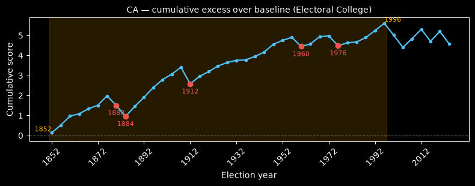

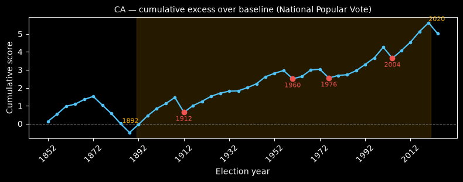

```python
render_spotlight("CA", category="core")
```

#### MO

MO

*Core — long-run F2-dominant bellwether*

**F1 — longest streak tolerating *k* misses**

|  | Metric | k=0 | k=1 | k=2 | k=3 |
| --- | --- | --- | --- | --- | --- |
| 0 | Electoral College | 13 | 26 | 27 | 29 |
| 1 | National Popular Vote | 13 | 24 | 26 | 29 |

**F2 — baseline-centered best window (used for selection/ranking)**

|  | Metric | Baseline | Window | Length | Hits | Misses | Miss Years | Score |
| --- | --- | --- | --- | --- | --- | --- | --- | --- |
| 0 | Electoral College | constant pooled | 1904–2004 | 26 | 25 | 1 | 1956 | 7.04 |
| 1 | Electoral College | time-varying | 1904–2004 | 26 | 25 | 1 | 1956 | 5.62 |
| 2 | National Popular Vote | constant pooled | 1904–1996 | 24 | 23 | 1 | 1956 | 6.62 |
| 3 | National Popular Vote | time-varying | 1876–1996 | 31 | 27 | 4 | 1880, 1896, 1900, 1956 | 5.15 |

**Party context** — MO last changed which party it voted for in **2000**.

|  | Metric | F2 Window | Party Flips Within Window |
| --- | --- | --- | --- |
| 0 | Electoral College | 1904–2004 | 10 |
| 1 | National Popular Vote | 1876–1996 | 10 |

**Recent margin snapshot**

|  | Year | D Votes | R Votes | Raw Margin (D-R) | State Margin % | National Margin % | Relative Margin % |
| --- | --- | --- | --- | --- | --- | --- | --- |
| 0 | 2016 | 1071068 | 1594511 | -523443 | -18.6 | 2.1 | -20.7 |
| 1 | 2020 | 1253014 | 1718736 | -465722 | -15.4 | 4.5 | -19.8 |
| 2 | 2024 | 1200599 | 1751986 | -551387 | -18.4 | -1.5 | -16.9 |

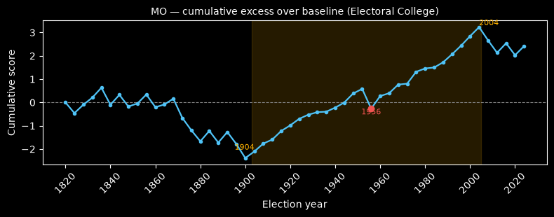

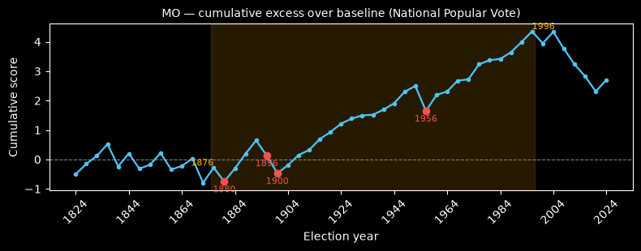

```python
render_spotlight("MO", category="core")
```

#### IN

IN

*Used to be — historical bellwether, now gone*

**F1 — longest streak tolerating *k* misses**

|  | Metric | k=0 | k=1 | k=2 | k=3 |
| --- | --- | --- | --- | --- | --- |
| 0 | Electoral College | 9 | 16 | 22 | 25 |
| 1 | National Popular Vote | 9 | 16 | 22 | 25 |

**F2 — baseline-centered best window (used for selection/ranking)**

|  | Metric | Baseline | Window | Length | Hits | Misses | Miss Years | Score |
| --- | --- | --- | --- | --- | --- | --- | --- | --- |
| 0 | Electoral College | constant pooled | 1816–1936 | 31 | 27 | 4 | 1836, 1848, 1876, 1916 | 5.59 |
| 1 | Electoral College | time-varying | 1816–1936 | 31 | 27 | 4 | 1836, 1848, 1876, 1916 | 5.79 |
| 2 | National Popular Vote | constant pooled | 1824–1936 | 29 | 25 | 4 | 1836, 1848, 1888, 1916 | 5.21 |
| 3 | National Popular Vote | time-varying | 1824–1936 | 29 | 25 | 4 | 1836, 1848, 1888, 1916 | 5.52 |

**Party context** — IN last changed which party it voted for in **2012**.

|  | Metric | F2 Window | Party Flips Within Window |
| --- | --- | --- | --- |
| 0 | Electoral College | 1816–1936 | 13 |
| 1 | National Popular Vote | 1824–1936 | 13 |

**Recent margin snapshot**

|  | Year | D Votes | R Votes | Raw Margin (D-R) | State Margin % | National Margin % | Relative Margin % |
| --- | --- | --- | --- | --- | --- | --- | --- |
| 0 | 2016 | 1033126 | 1557286 | -524160 | -19.2 | 2.1 | -21.3 |
| 1 | 2020 | 1242498 | 1729857 | -487359 | -16.1 | 4.5 | -20.5 |
| 2 | 2024 | 1163603 | 1720347 | -556744 | -19.0 | -1.5 | -17.5 |

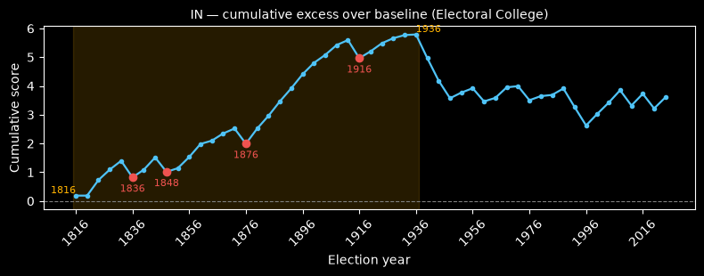

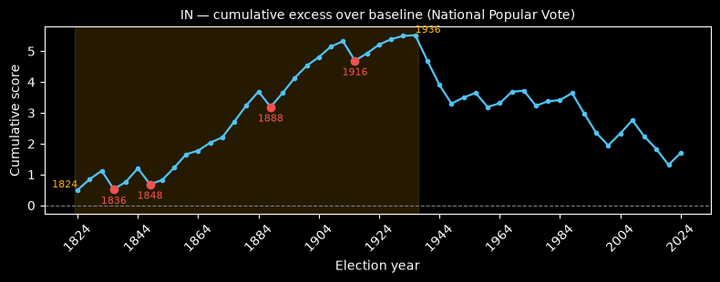

```python
render_spotlight("IN", category="used-to-be")
```

#### NV

NV

*Modern predictive state*

**F1 — longest streak tolerating *k* misses**

|  | Metric | k=0 | k=1 | k=2 | k=3 |
| --- | --- | --- | --- | --- | --- |
| 0 | Electoral College | 16 | 26 | 29 | 31 |
| 1 | National Popular Vote | 16 | 22 | 29 | 31 |

**F2 — baseline-centered best window (used for selection/ranking)**

|  | Metric | Baseline | Window | Length | Hits | Misses | Miss Years | Score |
| --- | --- | --- | --- | --- | --- | --- | --- | --- |
| 0 | Electoral College | constant pooled | 1912–2012 | 26 | 25 | 1 | 1976 | 7.04 |
| 1 | Electoral College | time-varying | 1912–2024 | 29 | 27 | 2 | 1976, 2016 | 6.18 |
| 2 | National Popular Vote | constant pooled | 1912–2024 | 29 | 27 | 2 | 1976, 2000 | 7.21 |
| 3 | National Popular Vote | time-varying | 1912–2024 | 29 | 27 | 2 | 1976, 2000 | 6.55 |

**Party context** — NV last changed which party it voted for in **2024**.

|  | Metric | F2 Window | Party Flips Within Window |
| --- | --- | --- | --- |
| 0 | Electoral College | 1912–2024 | 9 |
| 1 | National Popular Vote | 1912–2024 | 9 |

**Recent margin snapshot**

|  | Year | D Votes | R Votes | Raw Margin (D-R) | State Margin % | National Margin % | Relative Margin % |
| --- | --- | --- | --- | --- | --- | --- | --- |
| 0 | 2016 | 539260 | 512058 | 27202 | 2.4 | 2.1 | 0.3 |
| 1 | 2020 | 703486 | 669890 | 33596 | 2.4 | 4.5 | -2.1 |
| 2 | 2024 | 705197 | 751205 | -46008 | -3.1 | -1.5 | -1.6 |

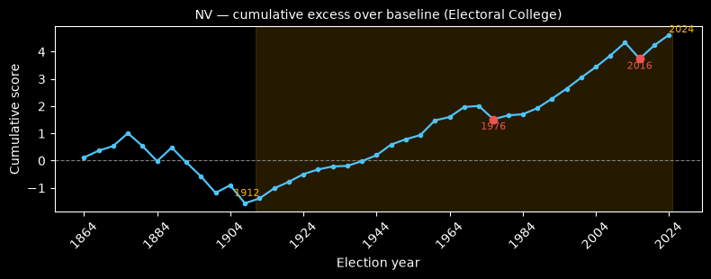

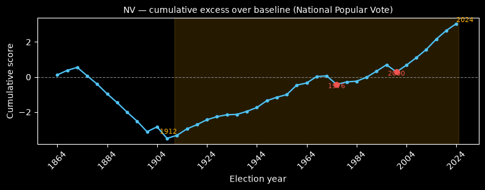

```python
render_spotlight("NV", category="modern-predictive")
```

#### NM

NM

*Modern predictive state*

**F1 — longest streak tolerating *k* misses**

|  | Metric | k=0 | k=1 | k=2 | k=3 |
| --- | --- | --- | --- | --- | --- |
| 0 | Electoral College | 16 | 22 | 26 | 28 |
| 1 | National Popular Vote | 16 | 28 | 29 | 29 |

**F2 — baseline-centered best window (used for selection/ranking)**

|  | Metric | Baseline | Window | Length | Hits | Misses | Miss Years | Score |
| --- | --- | --- | --- | --- | --- | --- | --- | --- |
| 0 | Electoral College | constant pooled | 1912–2012 | 26 | 24 | 2 | 1976, 2000 | 6.04 |
| 1 | Electoral College | time-varying | 1912–2012 | 26 | 24 | 2 | 1976, 2000 | 4.90 |
| 2 | National Popular Vote | constant pooled | 1912–2020 | 28 | 27 | 1 | 1976 | 7.89 |
| 3 | National Popular Vote | time-varying | 1912–2020 | 28 | 27 | 1 | 1976 | 7.16 |

**Party context** — NM last changed which party it voted for in **2008**.

|  | Metric | F2 Window | Party Flips Within Window |
| --- | --- | --- | --- |
| 0 | Electoral College | 1912–2012 | 8 |
| 1 | National Popular Vote | 1912–2020 | 8 |

**Recent margin snapshot**

|  | Year | D Votes | R Votes | Raw Margin (D-R) | State Margin % | National Margin % | Relative Margin % |
| --- | --- | --- | --- | --- | --- | --- | --- |
| 0 | 2016 | 385234 | 319667 | 65567 | 8.2 | 2.1 | 6.1 |
| 1 | 2020 | 501614 | 401894 | 99720 | 10.8 | 4.5 | 6.3 |
| 2 | 2024 | 478802 | 423391 | 55411 | 6.0 | -1.5 | 7.5 |

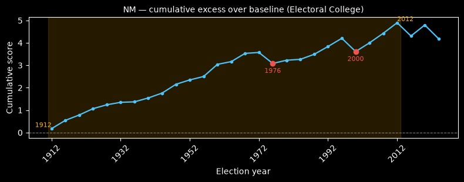

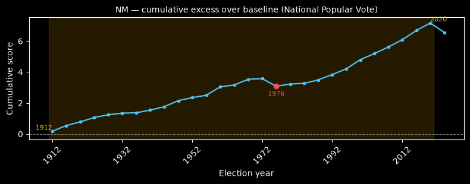

```python
render_spotlight("NM", category="modern-predictive")
```

#### TN

TN

*Bellwether that drifted during the Bush era*

**F1 — longest streak tolerating *k* misses**

|  | Metric | k=0 | k=1 | k=2 | k=3 |
| --- | --- | --- | --- | --- | --- |
| 0 | Electoral College | 11 | 20 | 24 | 25 |
| 1 | National Popular Vote | 9 | 18 | 22 | 24 |

**F2 — baseline-centered best window (used for selection/ranking)**

|  | Metric | Baseline | Window | Length | Hits | Misses | Miss Years | Score |
| --- | --- | --- | --- | --- | --- | --- | --- | --- |
| 0 | Electoral College | constant pooled | 1912–2004 | 24 | 22 | 2 | 1924, 1960 | 5.42 |
| 1 | Electoral College | time-varying | 1912–2004 | 24 | 22 | 2 | 1924, 1960 | 4.00 |
| 2 | National Popular Vote | constant pooled | 1912–1996 | 22 | 20 | 2 | 1924, 1960 | 4.99 |
| 3 | National Popular Vote | time-varying | 1912–1996 | 22 | 20 | 2 | 1924, 1960 | 3.20 |

**Party context** — TN last changed which party it voted for in **2000**.

|  | Metric | F2 Window | Party Flips Within Window |
| --- | --- | --- | --- |
| 0 | Electoral College | 1912–2004 | 11 |
| 1 | National Popular Vote | 1912–1996 | 10 |

**Recent margin snapshot**

|  | Year | D Votes | R Votes | Raw Margin (D-R) | State Margin % | National Margin % | Relative Margin % |
| --- | --- | --- | --- | --- | --- | --- | --- |
| 0 | 2016 | 870695 | 1522925 | -652230 | -26.0 | 2.1 | -28.1 |
| 1 | 2020 | 1143711 | 1852475 | -708764 | -23.2 | 4.5 | -27.7 |
| 2 | 2024 | 1056265 | 1966865 | -910600 | -29.7 | -1.5 | -28.2 |

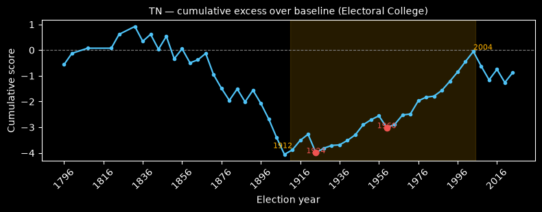

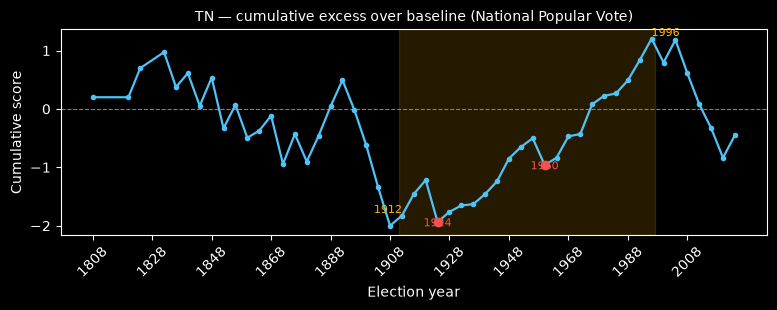

```python
render_spotlight("TN", category="recent-drift")
```

#### WI

WI

*Current predictive bloc ("Blue Wall")*

**F1 — longest streak tolerating *k* misses**

|  | Metric | k=0 | k=1 | k=2 | k=3 |
| --- | --- | --- | --- | --- | --- |
| 0 | Electoral College | 7 | 14 | 16 | 21 |
| 1 | National Popular Vote | 6 | 10 | 15 | 19 |

**F2 — baseline-centered best window (used for selection/ranking)**

|  | Metric | Baseline | Window | Length | Hits | Misses | Miss Years | Score |
| --- | --- | --- | --- | --- | --- | --- | --- | --- |
| 0 | Electoral College | constant pooled | 1860–2024 | 42 | 34 | 8 | 1884, 1916, 1924, 1944, 1960, 1988, 2000, 2004 | 4.99 |
| 1 | Electoral College | time-varying | 1860–2024 | 42 | 34 | 8 | 1884, 1916, 1924, 1944, 1960, 1988, 2000, 2004 | 5.08 |
| 2 | National Popular Vote | constant pooled | 1892–2000 | 28 | 23 | 5 | 1916, 1924, 1944, 1960, 1988 | 3.89 |
| 3 | National Popular Vote | time-varying | 1892–2024 | 34 | 27 | 7 | 1916, 1924, 1944, 1960, 1988, 2004, 2016 | 3.51 |

**Party context** — WI last changed which party it voted for in **2024**.

|  | Metric | F2 Window | Party Flips Within Window |
| --- | --- | --- | --- |
| 0 | Electoral College | 1860–2024 | 18 |
| 1 | National Popular Vote | 1892–2024 | 17 |

**Recent margin snapshot**

|  | Year | D Votes | R Votes | Raw Margin (D-R) | State Margin % | National Margin % | Relative Margin % |
| --- | --- | --- | --- | --- | --- | --- | --- |
| 0 | 2016 | 1382536 | 1405284 | -22748 | -0.8 | 2.1 | -2.9 |
| 1 | 2020 | 1630866 | 1610184 | 20682 | 0.6 | 4.5 | -3.8 |
| 2 | 2024 | 1668229 | 1697626 | -29397 | -0.9 | -1.5 | 0.6 |

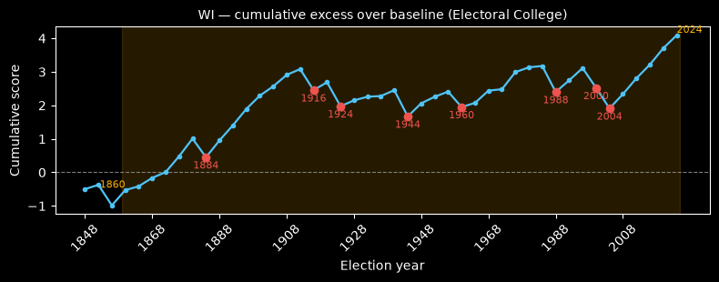

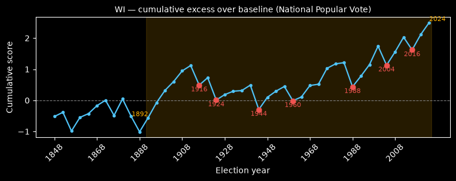

```python
render_spotlight("WI", category="modern-bloc")
```

#### MI

MI

*Current predictive bloc ("Blue Wall")*

**F1 — longest streak tolerating *k* misses**

|  | Metric | k=0 | k=1 | k=2 | k=3 |
| --- | --- | --- | --- | --- | --- |
| 0 | Electoral College | 6 | 8 | 13 | 15 |
| 1 | National Popular Vote | 6 | 9 | 13 | 16 |

**F2 — baseline-centered best window (used for selection/ranking)**

|  | Metric | Baseline | Window | Length | Hits | Misses | Miss Years | Score |
| --- | --- | --- | --- | --- | --- | --- | --- | --- |
| 0 | Electoral College | constant pooled | 1860–2024 | 42 | 32 | 10 | 1884, 1892, 1912, 1916, 1940, 1948, 1968, 1976... | 2.99 |
| 1 | Electoral College | time-varying | 1836–2024 | 48 | 36 | 12 | 1848, 1856, 1884, 1892, 1912, 1916, 1940, 1948... | 3.21 |
| 2 | National Popular Vote | constant pooled | 1920–2000 | 21 | 17 | 4 | 1940, 1948, 1968, 1976 | 2.67 |
| 3 | National Popular Vote | time-varying | 1980–2024 | 12 | 10 | 2 | 2004, 2016 | 2.47 |

**Party context** — MI last changed which party it voted for in **2024**.

|  | Metric | F2 Window | Party Flips Within Window |
| --- | --- | --- | --- |
| 0 | Electoral College | 1836–2024 | 15 |
| 1 | National Popular Vote | 1980–2024 | 4 |

**Recent margin snapshot**

|  | Year | D Votes | R Votes | Raw Margin (D-R) | State Margin % | National Margin % | Relative Margin % |
| --- | --- | --- | --- | --- | --- | --- | --- |
| 0 | 2016 | 2268839 | 2279543 | -10704 | -0.2 | 2.1 | -2.3 |
| 1 | 2020 | 2804040 | 2649852 | 154188 | 2.8 | 4.5 | -1.7 |
| 2 | 2024 | 2736533 | 2816636 | -80103 | -1.4 | -1.5 | 0.1 |

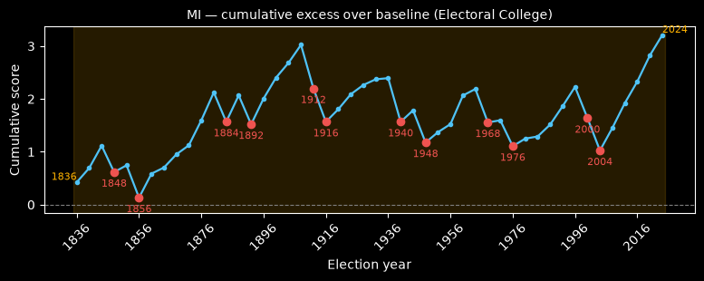

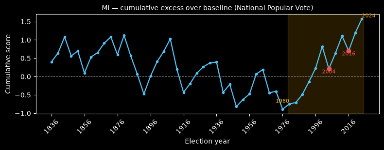

```python
render_spotlight("MI", category="modern-bloc")
```

#### DE

DE

*Honorable mention — used to be swingy, locked in since 1992*

**F1 — longest streak tolerating *k* misses**

|  | Metric | k=0 | k=1 | k=2 | k=3 |
| --- | --- | --- | --- | --- | --- |
| 0 | Electoral College | 12 | 16 | 20 | 27 |
| 1 | National Popular Vote | 13 | 18 | 22 | 30 |

**F2 — baseline-centered best window (used for selection/ranking)**

|  | Metric | Baseline | Window | Length | Hits | Misses | Miss Years | Score |
| --- | --- | --- | --- | --- | --- | --- | --- | --- |
| 0 | Electoral College | constant pooled | 1892–1996 | 27 | 24 | 3 | 1916, 1932, 1948 | 5.35 |
| 1 | Electoral College | time-varying | 1892–1996 | 27 | 24 | 3 | 1916, 1932, 1948 | 4.16 |
| 2 | National Popular Vote | constant pooled | 1884–2020 | 35 | 31 | 4 | 1916, 1932, 1948, 2004 | 7.11 |
| 3 | National Popular Vote | time-varying | 1872–2020 | 38 | 33 | 5 | 1880, 1916, 1932, 1948, 2004 | 7.28 |

**Party context** — DE last changed which party it voted for in **1992**.

|  | Metric | F2 Window | Party Flips Within Window |
| --- | --- | --- | --- |
| 0 | Electoral College | 1892–1996 | 10 |
| 1 | National Popular Vote | 1872–2020 | 11 |

**Recent margin snapshot**

|  | Year | D Votes | R Votes | Raw Margin (D-R) | State Margin % | National Margin % | Relative Margin % |
| --- | --- | --- | --- | --- | --- | --- | --- |
| 0 | 2016 | 235603 | 185127 | 50476 | 11.4 | 2.1 | 9.3 |
| 1 | 2020 | 296268 | 200603 | 95665 | 19.0 | 4.5 | 14.5 |
| 2 | 2024 | 289758 | 214351 | 75407 | 14.7 | -1.5 | 16.2 |

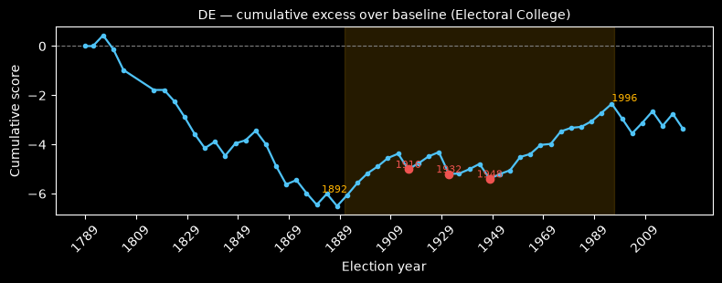

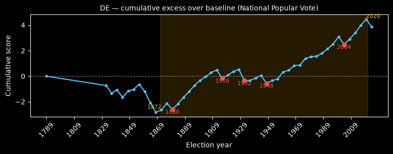

```python
render_spotlight("DE", category="honorable-mention")
```

#### MD

MD

*Honorable mention — used to be swingy, locked in since 1992*

**F1 — longest streak tolerating *k* misses**

|  | Metric | k=0 | k=1 | k=2 | k=3 |
| --- | --- | --- | --- | --- | --- |
| 0 | Electoral College | 14 | 19 | 22 | 27 |
| 1 | National Popular Vote | 16 | 21 | 24 | 30 |

**F2 — baseline-centered best window (used for selection/ranking)**

|  | Metric | Baseline | Window | Length | Hits | Misses | Miss Years | Score |
| --- | --- | --- | --- | --- | --- | --- | --- | --- |
| 0 | Electoral College | constant pooled | 1892–1996 | 27 | 24 | 3 | 1948, 1968, 1980 | 5.35 |
| 1 | Electoral College | time-varying | 1892–1996 | 27 | 24 | 3 | 1948, 1968, 1980 | 4.16 |
| 2 | National Popular Vote | constant pooled | 1884–2020 | 35 | 31 | 4 | 1948, 1968, 1980, 2004 | 7.11 |
| 3 | National Popular Vote | time-varying | 1876–2020 | 37 | 32 | 5 | 1880, 1948, 1968, 1980, 2004 | 7.11 |

**Party context** — MD last changed which party it voted for in **1992**.

|  | Metric | F2 Window | Party Flips Within Window |
| --- | --- | --- | --- |
| 0 | Electoral College | 1892–1996 | 10 |
| 1 | National Popular Vote | 1876–2020 | 10 |

**Recent margin snapshot**

|  | Year | D Votes | R Votes | Raw Margin (D-R) | State Margin % | National Margin % | Relative Margin % |
| --- | --- | --- | --- | --- | --- | --- | --- |
| 0 | 2016 | 1677928 | 943169 | 734759 | 26.4 | 2.1 | 24.3 |
| 1 | 2020 | 1985023 | 976414 | 1008609 | 33.2 | 4.5 | 28.8 |
| 2 | 2024 | 1902577 | 1035550 | 867027 | 28.5 | -1.5 | 30.0 |

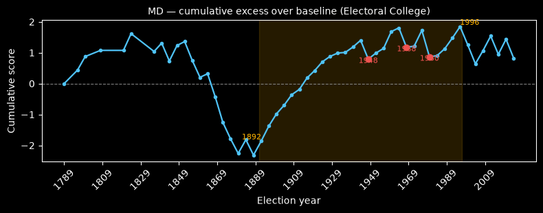

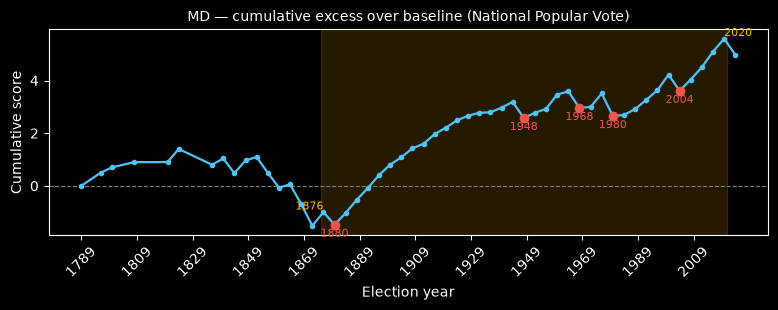

```python
render_spotlight("MD", category="honorable-mention")
```

#### CT

CT

*Honorable mention — used to be swingy, locked in since 1992*

**F1 — longest streak tolerating *k* misses**

|  | Metric | k=0 | k=1 | k=2 | k=3 |
| --- | --- | --- | --- | --- | --- |
| 0 | Electoral College | 6 | 10 | 14 | 19 |
| 1 | National Popular Vote | 14 | 18 | 22 | 27 |

**F2 — baseline-centered best window (used for selection/ranking)**

|  | Metric | Baseline | Window | Length | Hits | Misses | Miss Years | Score |
| --- | --- | --- | --- | --- | --- | --- | --- | --- |
| 0 | Electoral College | constant pooled | 1860–1996 | 35 | 28 | 7 | 1876, 1888, 1916, 1932, 1948, 1968, 1976 | 3.82 |
| 1 | Electoral College | time-varying | 1836–1928 | 24 | 19 | 5 | 1844, 1856, 1876, 1888, 1916 | 3.26 |
| 2 | National Popular Vote | constant pooled | 1860–2020 | 41 | 35 | 6 | 1916, 1932, 1948, 1968, 1976, 2004 | 7.02 |
| 3 | National Popular Vote | time-varying | 1836–2020 | 47 | 39 | 8 | 1844, 1856, 1916, 1932, 1948, 1968, 1976, 2004 | 7.19 |

**Party context** — CT last changed which party it voted for in **1992**.

|  | Metric | F2 Window | Party Flips Within Window |
| --- | --- | --- | --- |
| 0 | Electoral College | 1836–1928 | 9 |
| 1 | National Popular Vote | 1836–2020 | 14 |

**Recent margin snapshot**

|  | Year | D Votes | R Votes | Raw Margin (D-R) | State Margin % | National Margin % | Relative Margin % |
| --- | --- | --- | --- | --- | --- | --- | --- |
| 0 | 2016 | 897572 | 673215 | 224357 | 13.6 | 2.1 | 11.5 |
| 1 | 2020 | 1080831 | 714717 | 366114 | 20.1 | 4.5 | 15.6 |
| 2 | 2024 | 992053 | 736918 | 255135 | 14.5 | -1.5 | 16.0 |

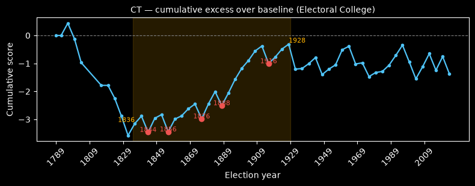

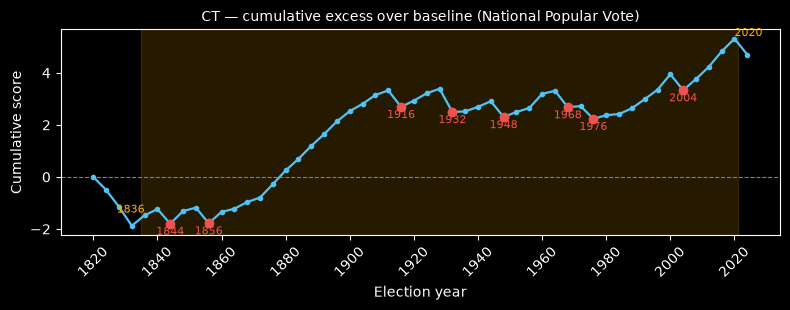

```python
render_spotlight("CT", category="honorable-mention")
```

#### NJ

NJ

*Honorable mention — used to be swingy, locked in since 1992*

**F1 — longest streak tolerating *k* misses**

|  | Metric | k=0 | k=1 | k=2 | k=3 |
| --- | --- | --- | --- | --- | --- |
| 0 | Electoral College | 7 | 14 | 21 | 27 |
| 1 | National Popular Vote | 8 | 16 | 23 | 30 |

**F2 — baseline-centered best window (used for selection/ranking)**

|  | Metric | Baseline | Window | Length | Hits | Misses | Miss Years | Score |
| --- | --- | --- | --- | --- | --- | --- | --- | --- |
| 0 | Electoral College | constant pooled | 1892–1996 | 27 | 24 | 3 | 1916, 1948, 1976 | 5.35 |
| 1 | Electoral College | time-varying | 1892–1996 | 27 | 24 | 3 | 1916, 1948, 1976 | 4.16 |
| 2 | National Popular Vote | constant pooled | 1804–2020 | 54 | 44 | 10 | 1828, 1836, 1844, 1864, 1868, 1880, 1916, 1948... | 7.15 |
| 3 | National Popular Vote | time-varying | 1872–2020 | 38 | 33 | 5 | 1880, 1916, 1948, 1976, 2004 | 7.28 |

**Party context** — NJ last changed which party it voted for in **1992**.

|  | Metric | F2 Window | Party Flips Within Window |
| --- | --- | --- | --- |
| 0 | Electoral College | 1892–1996 | 8 |
| 1 | National Popular Vote | 1872–2020 | 9 |

**Recent margin snapshot**

|  | Year | D Votes | R Votes | Raw Margin (D-R) | State Margin % | National Margin % | Relative Margin % |
| --- | --- | --- | --- | --- | --- | --- | --- |
| 0 | 2016 | 2148278 | 1601933 | 546345 | 14.1 | 2.1 | 12.0 |
| 1 | 2020 | 2608400 | 1883313 | 725087 | 15.9 | 4.5 | 11.5 |
| 2 | 2024 | 2220713 | 1968215 | 252498 | 5.9 | -1.5 | 7.4 |

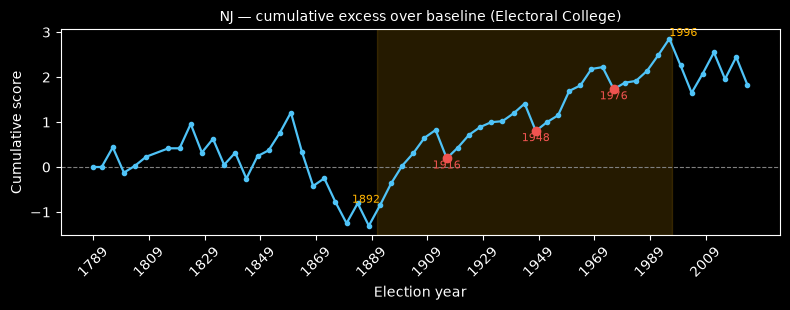

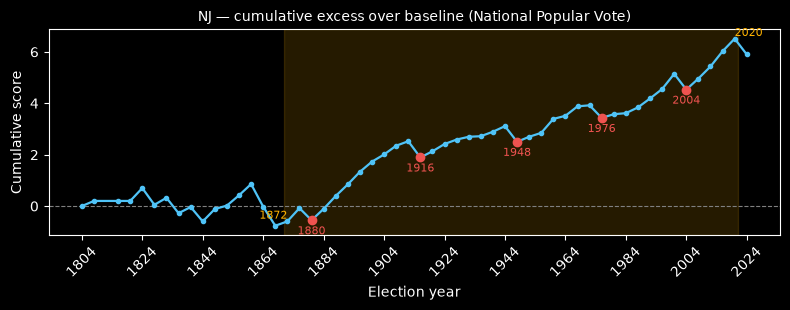

```python
render_spotlight("NJ", category="honorable-mention")
```